# Progetto Statistica Inferenziale

## 5.2 Età della madre

Prima di analizziare le potenziali differenze per la variabile **Età della madre** tra i due sessi, creo un boxplot per la variabile *Età della madre* condizionata alla variabile *Sesso* ed estrapolo le statistiche di sintesi con la funzione `summary()`

```r
summary(df$Anni.madre[df$Sesso=="F"])
```

```
##    Min. 1st Qu.  Median    Mean 3rd Qu.    Max.
##    1.00   25.00   28.00   28.12   32.00   44.00
```

```r
summary(df$Anni.madre[df$Sesso=="M"])
```

```
##    Min. 1st Qu.  Median    Mean 3rd Qu.    Max.
##    0.00   25.00   28.00   28.21   32.00   46.00
```

Valori *anomali* per età della madre:

- `[df$Sesso=="F"]`: Anni.madre = `Min. 1.00`
- `[df$Sesso=="M"]`: Anni.madre = `Min. 0.00`

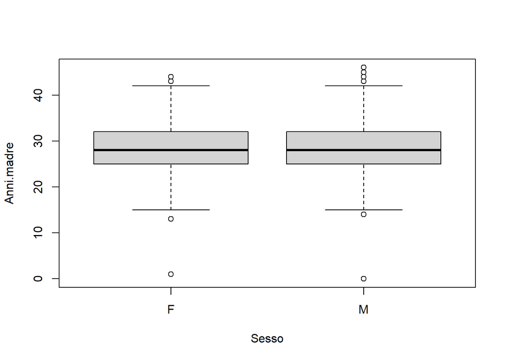

```r
boxplot(Anni.madre~Sesso, data = df)
```

Saggiamo la normale distribuzione dei dati:

```r
shapiro.test(Anni.madre)
```

```
##
##  Shapiro-Wilk normality test
##
## data:  Anni.madre
## W = 0.99308, p-value = 1.639e-09
```

Come già visto in precedenza la variabile *Anni.madre* contenuta nel dataset non si distribuisce normalmente.

Proviamo ad effettuare uno `shapiro.test()` raggruppando il datatset per la variabile *Sesso.*

```r
df %>%
  group_by(Sesso)%>%
  shapiro_test(Anni.madre)
```

```
## # A tibble: 2 x 4
##   Sesso variable   statistic          p
##   <fct> <chr>          <dbl>      <dbl>
## 1 F     Anni.madre     0.993 0.0000122
## 2 M     Anni.madre     0.992 0.00000226
```

Anche qui il *p-value* è < di 0.05, pertanto i dati non si distribuiscono normalmente.

Saggiamo l’uguaglianza delle *varianze* tra i gruppi:

```r
var_anniMadre.sesso<-var.test(Anni.madre~Sesso,
                         data = df,
                         alternative = "two.sided")
var_anniMadre.sesso
```

```
##
##  F test to compare two variances
##
## data:  Anni.madre by Sesso
## F = 0.93319, num df = 1255, denom df = 1243, p-value = 0.2218
## alternative hypothesis: true ratio of variances is not equal to 1
## 95 percent confidence interval:
##  0.8351581 1.0426891
## sample estimates:
## ratio of variances
##          0.9331861
```

Visualizzo graficamente il risultato del `var.test()`

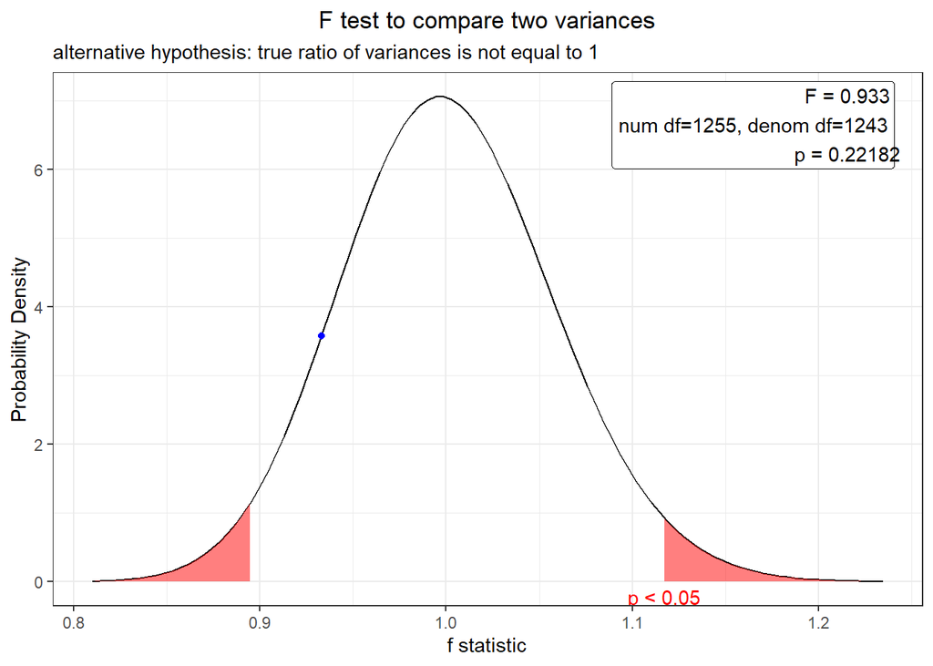

```r
plot(var_anniMadre.sesso)
```

**T di Student**

```r
tAnnimadreSesso <- t.test(data = df,
                          Anni.madre~Sesso)
tAnnimadreSesso
```

```
##
##  Welch Two Sample t-test
##
## data:  Anni.madre by Sesso
## t = -0.46242, df = 2493.1, p-value = 0.6438
## alternative hypothesis: true difference in means between group F and group M is not equal to 0
## 95 percent confidence interval:
##  -0.5113569  0.3162036
## sample estimates:
## mean in group F mean in group M
##        28.11545        28.21302
```

Di seguito l’esito del t test, rappresentato graficamente:

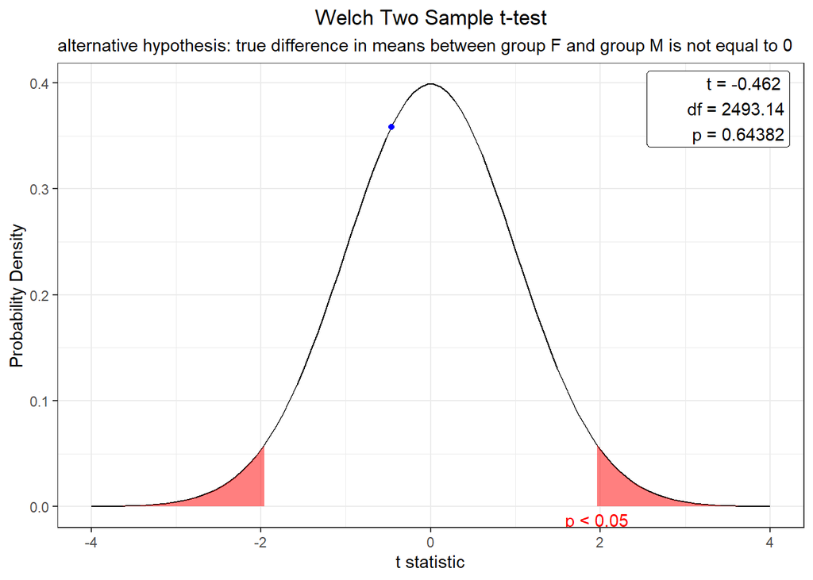

```r
plot(tAnnimadreSesso)
```

**Wilcox Test**

```r
wilcoxTestAnniMadreSesso <- wilcox.test(df$Anni.madre~df$Sesso,
                                        conf.level = 0.95,
                                        alternative = "two.sided",
                                        p.adjust.methods = "bonferroni")
wilcoxTestAnniMadreSesso
```

```
##
##  Wilcoxon rank sum test with continuity correction
##
## data:  df$Anni.madre by df$Sesso
## W = 774995, p-value = 0.7292
## alternative hypothesis: true location shift is not equal to 0
```

Ricordo che in questo caso il nostro sistema di ipotesi è:

- H0: Media Età madre F = Media Età madre M
- H1: Media Età madre F != Media Età madre M

Anche qui per entrambi i test il livello di significatività (Alfa) che delimita le zone di rifiuto è fissato al 5% (nella funzione indicato con `conf.level = 0.95` ovvero 1-Alfa)

Entrambi i test restituiscono un **p-value > Alfa** pertanto **Non rifiutiamo l’ipotesi nulla.**

## 5.3 Settimane di Gestazione

Prima di analizziare le potenziali differenze per la variabile **Gestazione** tra i due sessi, creo un boxplot per la variabile *Gestazione* condizionata alla variabile *Sesso* ed estrapolo le statistiche di sintesi con la funzione `summary()`, per le neonate F (`[df$Sesso=="F"]`) e per i neonati M (`[df$Sesso=="M"]`).

```r
summary(df$Gestazione[df$Sesso=="F"])
```

```
##    Min. 1st Qu.  Median    Mean 3rd Qu.    Max.
##   25.00   38.00   39.00   38.73   40.00   43.00
```

```r
summary(df$Gestazione[df$Sesso=="M"])
```

```
##    Min. 1st Qu.  Median    Mean 3rd Qu.    Max.
##   27.00   38.00   40.00   39.23   40.00   43.00
```

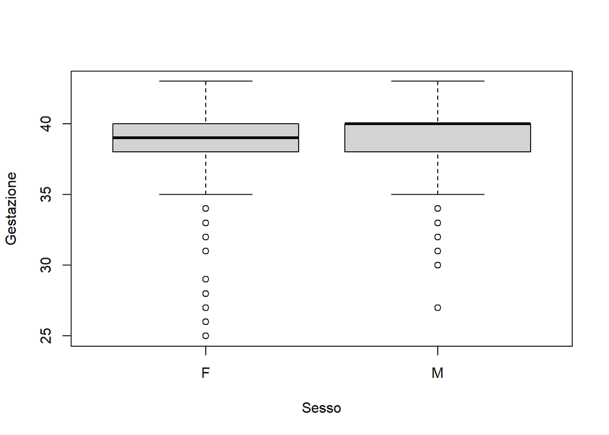

```r
boxplot(Gestazione~Sesso, data = df)
```

Saggiamo la normale distribuzione dei dati:

```r
shapiro.test(Gestazione)
```

```
##
##  Shapiro-Wilk normality test
##
## data:  Gestazione
## W = 0.83328, p-value < 2.2e-16
```

Come già visto in precedenza la variabile *Gestazione* contenuta nel dataset non si distribuisce normalmente.

Proviamo ad effettuare uno `shapiro.test()` raggruppando il datatset per la variabile *Sesso.*

```r
df %>%
  group_by(Sesso)%>%
  shapiro_test(Gestazione)
```

```
## # A tibble: 2 x 4
##   Sesso variable   statistic        p
##   <fct> <chr>          <dbl>    <dbl>
## 1 F     Gestazione     0.826 7.25e-35
## 2 M     Gestazione     0.845 3.44e-33
```

Anche qui il *p-value* è < di 0.05, pertanto i dati non si distribuiscono normalmente.

Saggiamo l’uguaglianza delle *varianze* tra i gruppi:

```r
var_gestazione.sesso<-var.test(Gestazione~Sesso,
                              data = df,
                              alternative = "two.sided")
var_gestazione.sesso
```

```
##
##  F test to compare two variances
##
## data:  Gestazione by Sesso
## F = 1.3651, num df = 1255, denom df = 1243, p-value = 4.114e-08
## alternative hypothesis: true ratio of variances is not equal to 1
## 95 percent confidence interval:
##  1.221699 1.525282
## sample estimates:
## ratio of variances
##           1.365098
```

Visualizzo graficamente il risultato del `var.test()`

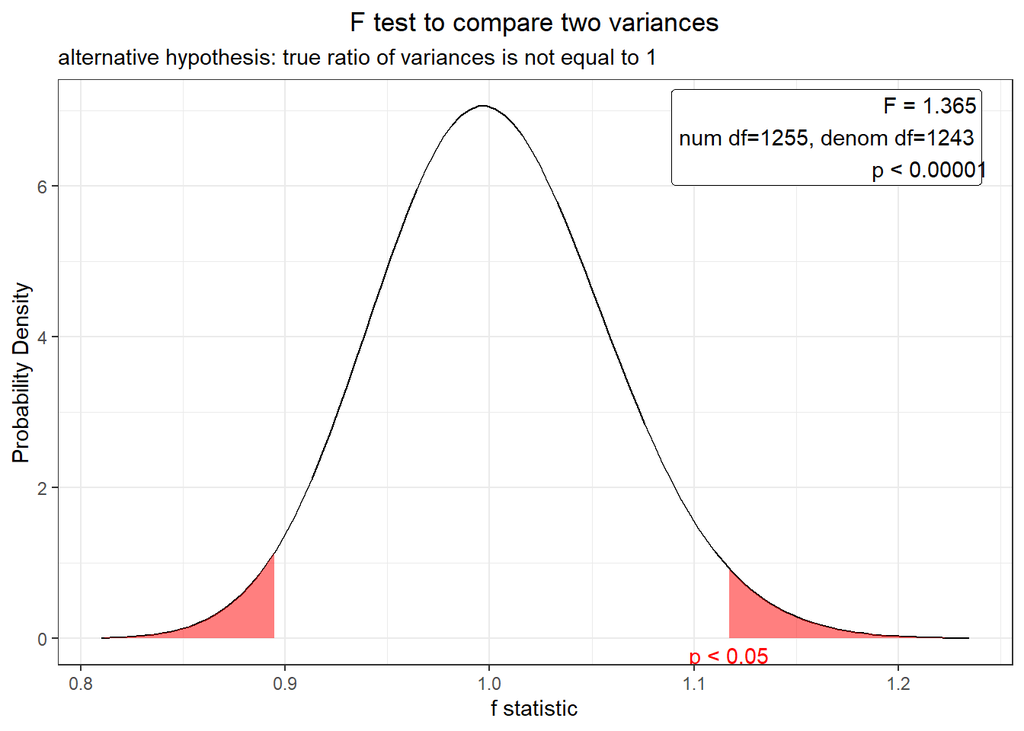

```r
plot(var_gestazione.sesso)
```

**T di Student**

```r
tGestazioneSesso <- t.test(data = df,
                           Gestazione~Sesso)
tGestazioneSesso
```

```
##
##  Welch Two Sample t-test
##
## data:  Gestazione by Sesso
## t = -6.7072, df = 2446.6, p-value = 2.456e-11
## alternative hypothesis: true difference in means between group F and group M is not equal to 0
## 95 percent confidence interval:
##  -0.6418172 -0.3514294
## sample estimates:
## mean in group F mean in group M
##        38.73328        39.22990
```

Di seguito l’esito del t-test, rappresentato graficamente:

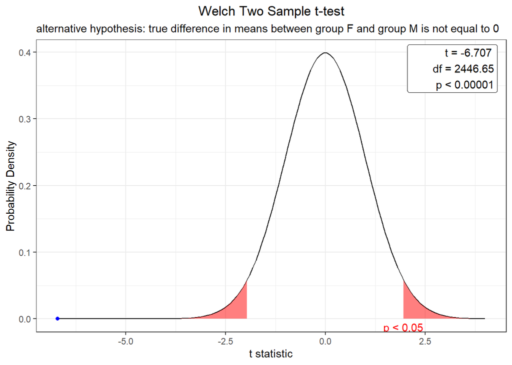

```r
plot(tGestazioneSesso)
```

**Wilcox Test**

```r
wilcoxTestGestazioneSesso <- wilcox.test(df$Gestazione~df$Sesso,
                                         conf.level = 0.95,
                                         alternative = "two.sided",
                                         p.adjust.methods = "bonferroni")
wilcoxTestGestazioneSesso
```

```
##
##  Wilcoxon rank sum test with continuity correction
##
## data:  df$Gestazione by df$Sesso
## W = 652659, p-value = 2.937e-13
## alternative hypothesis: true location shift is not equal to 0
```

Ricordo che in questo caso il nostro sistema di ipotesi è:

- H0: Media Gestazione F = Media Gestazione M
- H1: Media Gestazione F != Media Gestazione M

Anche qui per entrambi i test il livello di significatività (Alfa) che delimita le zone di rifiuto è fissato al 5% (nella funzione indicato con `conf.level = 0.95` ovvero 1-Alfa)

Entrambi i test restituiscono un **p-value < Alfa** pertanto **l’ipotesi nulla è rifiutata a favore dell’ipotesi alternativa.**

## 5.4 Lunghezza

Prima di analizziare le potenziali differenze per la variabile **Lunghezza** tra i due sessi, creo un boxplot per la variabile *Lunghezza* condizionata alla variabile *Sesso* ed estrapolo le statistiche di sintesi con la funzione `summary()`, per le neonate F (`[df$Sesso=="F"]`) e per i neonati M (`[df$Sesso=="M"]`).

```r
summary(df$Lunghezza[df$Sesso=="F"])
```

```
##    Min. 1st Qu.  Median    Mean 3rd Qu.    Max.
##   310.0   480.0   490.0   489.8   505.0   565.0
```

```r
summary(df$Lunghezza[df$Sesso=="M"])
```

```
##    Min. 1st Qu.  Median    Mean 3rd Qu.    Max.
##   320.0   490.0   500.0   499.7   515.0   560.0
```

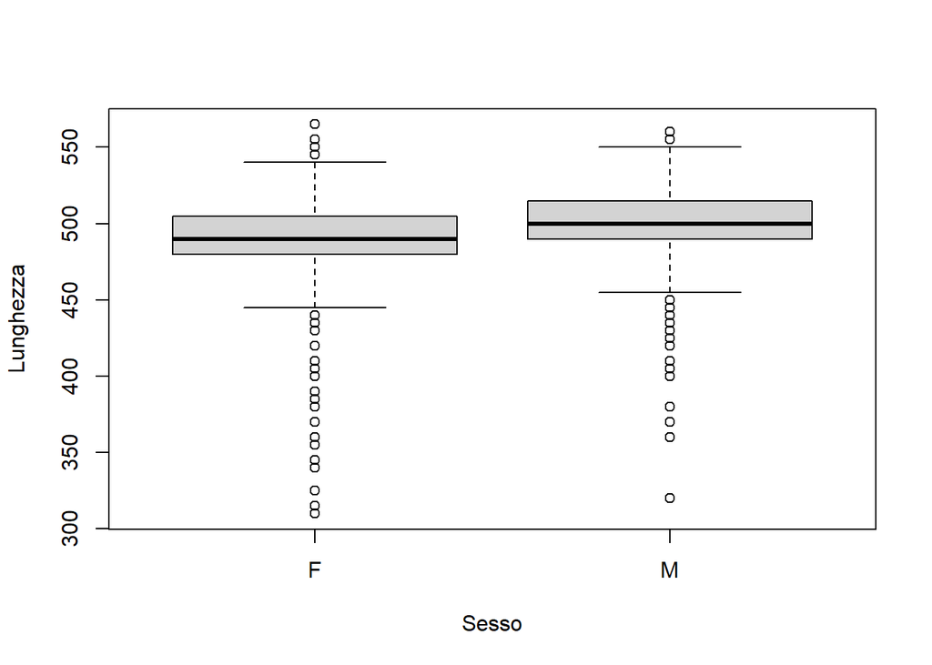

```r
boxplot(Lunghezza~Sesso, data = df)
```

Saggiamo la normale distribuzione dei dati:

```r
shapiro.test(Lunghezza)
```

```
##
##  Shapiro-Wilk normality test
##
## data:  Lunghezza
## W = 0.90941, p-value < 2.2e-16
```

Come già visto in precedenza la variabile *Lunghezza* contenuta nel dataset non si distribuisce normalmente.

Proviamo ad effettuare uno `shapiro.test()` raggruppando il datatset per la variabile *Sesso.*

```r
df %>%
  group_by(Sesso)%>%
  shapiro_test(Lunghezza)
```

```
## # A tibble: 2 x 4
##   Sesso variable  statistic        p
##   <fct> <chr>         <dbl>    <dbl>
## 1 F     Lunghezza     0.900 6.57e-28
## 2 M     Lunghezza     0.920 4.16e-25
```

Anche qui il *p-value* è < di 0.05, pertanto i dati non si distribuiscono normalmente.

Saggiamo l’uguaglianza delle *varianze* tra i gruppi:

```r
var_lunghezza.sesso<-var.test(Lunghezza~Sesso,
                               data = df,
                               alternative = "two.sided")
var_lunghezza.sesso
```

```
##
##  F test to compare two variances
##
## data:  Lunghezza by Sesso
## F = 1.312, num df = 1255, denom df = 1243, p-value = 1.673e-06
## alternative hypothesis: true ratio of variances is not equal to 1
## 95 percent confidence interval:
##  1.174205 1.465987
## sample estimates:
## ratio of variances
##           1.312029
```

Visualizzo graficamente il risultato del `var.test()`

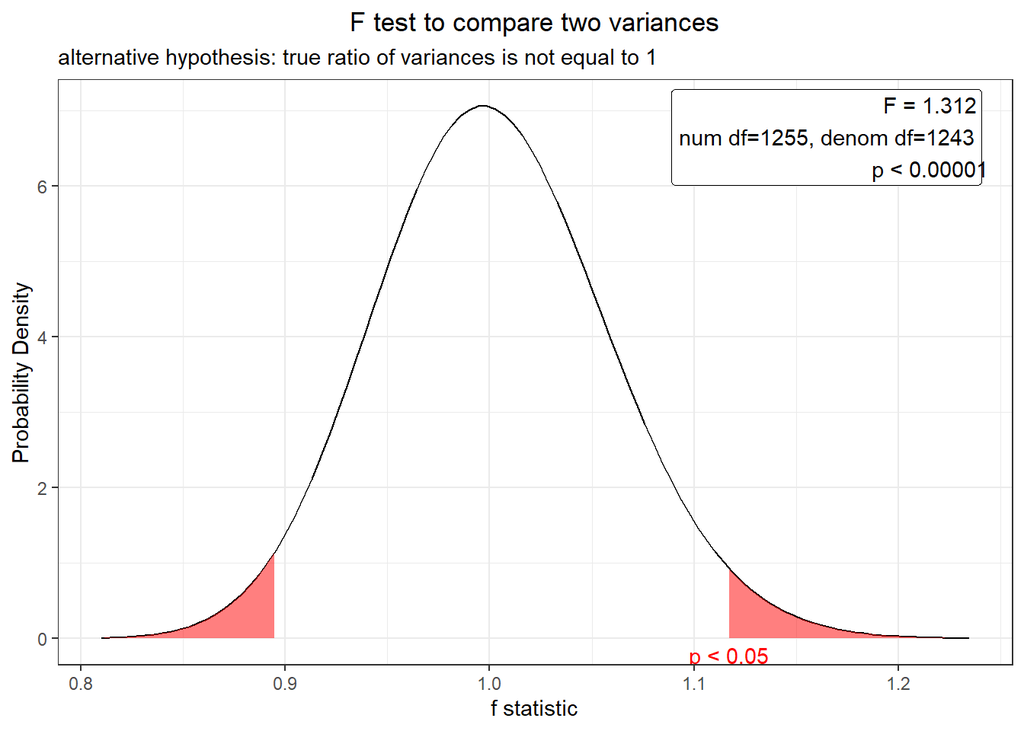

```r
plot(var_lunghezza.sesso)
```

**T di Student**

```r
tLunghezzaSesso <- t.test(data = df,
                          Lunghezza~Sesso)
tLunghezzaSesso
```

```
##
##  Welch Two Sample t-test
##
## data:  Lunghezza by Sesso
## t = -9.582, df = 2459.3, p-value < 2.2e-16
## alternative hypothesis: true difference in means between group F and group M is not equal to 0
## 95 percent confidence interval:
##  -11.929470  -7.876273
## sample estimates:
## mean in group F mean in group M
##        489.7643        499.6672
```

Di seguito l’esito del t-test, rappresentato graficamente:

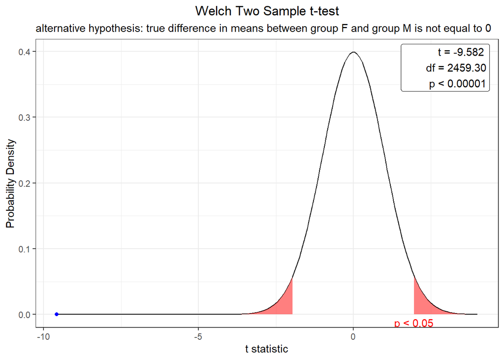

```r
plot(tLunghezzaSesso)
```

**Wilcox Test**

```r
wilcoxTestLunghezzaSesso <- wilcox.test(df$Lunghezza~df$Sesso,
                                        conf.level = 0.95,
                                        alternative = "two.sided",
                                        p.adjust.methods = "bonferroni")
wilcoxTestLunghezzaSesso
```

```
##
##  Wilcoxon rank sum test with continuity correction
##
## data:  df$Lunghezza by df$Sesso
## W = 594455, p-value < 2.2e-16
## alternative hypothesis: true location shift is not equal to 0
```

Ricordo che in questo caso il nostro sistema di ipotesi è:

- H0: Media Lunghezza F = Media Lunghezza M
- H1: Media Lunghezza F != Media Lunghezza M

Anche qui per entrambi i test il livello di significatività (Alfa) che delimita le zone di rifiuto è fissato al 5% (nella funzione indicato con `conf.level = 0.95` ovvero 1-Alfa)

Entrambi i test restituiscono un **p-value < Alfa** pertanto **l’ipotesi nulla è rifiutata a favore dell’ipotesi alternativa.**